# Analyse de l’utilité de données perturbées par une Cell Key Method

2024-07-16

# Introduction

Nous allons étudier la perte d’information de données perturbées par une Cell Key Method.

## Données utilisées

Pour faire notre analyse, nous avons à notre disposition des données Pôle Emploie original regroupant 5 tableaux ayant chacun des spécificités différentes comme la catégorie, le quartier prioritaire, le sexe, la catégorie d’age, le niveau de formation, dur et si l’individu est au RSA. Une premiere présentation de ces données peut être faite comme suit:

```r
str(liste_tableaux)
```

```
## List of 5
##  $ :Classes 'data.table' and 'data.frame':   33512 obs. of  7 variables:
##   ..$ CATEG    : chr [1:33512] "E" "D" "E" "E" ...
##   ..$ PLG_QP   : chr [1:33512] "QP093002" "QP071002" "QP095035" "QP062039" ...
##   ..$ SEXE     : chr [1:33512] "2" "1" "1" "2" ...
##   ..$ nb_obs   : num [1:33512] 1 1 1 1 1 1 1 1 1 1 ...
##   ..$ rkeys_tot: num [1:33512] 0.00465 0.00679 0.01077 0.01201 0.01552 ...
##   ..$ rkeys_max: num [1:33512] 1 1 1 1 0.997 ...
##   ..$ ck       : num [1:33512] 0.298 0.386 0.393 0.934 0.967 ...
##   ..- attr(*, ".internal.selfref")=<externalptr>
##  $ :Classes 'data.table' and 'data.frame':   128625 obs. of  8 variables:
##   ..$ CATEG    : chr [1:128625] "DE" "D" "E" "E" ...
##   ..$ PLG_QP   : chr [1:128625] "QP093025" "QP093025" "QP060005" "QP060005" ...
##   ..$ AGE_3c   : chr [1:128625] "[50,120]" "[50,120]" "[0,26)" "[0,26)" ...
##   ..$ SEXE     : chr [1:128625] "2" "2" "Ensemble" "2" ...
##   ..$ nb_obs   : num [1:128625] 1 1 1 1 1 1 1 1 1 1 ...
##   ..$ rkeys_tot: num [1:128625] 0.000353 0.000353 0.000576 0.000576 0.000722 ...
##   ..$ rkeys_max: num [1:128625] 0.000353 0.000353 0.000576 0.000576 0.000722 ...
##   ..$ ck       : num [1:128625] 0.000353 0.000353 0.000576 0.000576 0.000722 ...
##   ..- attr(*, ".internal.selfref")=<externalptr>
##  $ :Classes 'data.table' and 'data.frame':   162055 obs. of  8 variables:
##   ..$ CATEG    : chr [1:162055] "DE" "E" "E" "DE" ...
##   ..$ PLG_QP   : chr [1:162055] "QP067005" "QP067005" "QP067005" "QP062003" ...
##   ..$ NIVFOR   : chr [1:162055] "BAC" "BAC" "BAC" "INFCAPBEP" ...
##   ..$ SEXE     : chr [1:162055] "1" "Ensemble" "1" "2" ...
##   ..$ nb_obs   : num [1:162055] 1 1 1 1 1 1 1 1 1 1 ...
##   ..$ rkeys_tot: num [1:162055] 4.62e-05 4.62e-05 4.62e-05 1.31e-04 1.31e-04 ...
##   ..$ rkeys_max: num [1:162055] 4.62e-05 4.62e-05 4.62e-05 1.31e-04 1.31e-04 ...
##   ..$ ck       : num [1:162055] 4.62e-05 4.62e-05 4.62e-05 1.31e-04 1.31e-04 ...
##   ..- attr(*, ".internal.selfref")=<externalptr>
##  $ :Classes 'data.table' and 'data.frame':   150020 obs. of  8 variables:
##   ..$ CATEG    : chr [1:150020] "D" "D" "C" "D" ...
##   ..$ PLG_QP   : chr [1:150020] "QP062003" "QP062003" "QP973019" "QP062030" ...
##   ..$ DUR      : chr [1:150020] "Dur2" "Dur2" "Dur4" "Dur2" ...
##   ..$ SEXE     : chr [1:150020] "Ensemble" "2" "2" "2" ...
##   ..$ nb_obs   : num [1:150020] 1 1 1 1 1 1 1 1 1 1 ...
##   ..$ rkeys_tot: num [1:150020] 0.000131 0.000131 0.000231 0.000286 0.000353 ...
##   ..$ rkeys_max: num [1:150020] 0.000131 0.000131 0.000231 0.000286 0.000353 ...
##   ..$ ck       : num [1:150020] 0.000131 0.000131 0.000231 0.000286 0.000353 ...
##   ..- attr(*, ".internal.selfref")=<externalptr>
##  $ :Classes 'data.table' and 'data.frame':   33315 obs. of  7 variables:
##   ..$ CATEG    : chr [1:33315] "B" "E" "DE" "D" ...
##   ..$ PLG_QP   : chr [1:33315] "QP973007" "QP971010" "QP071002" "QP071002" ...
##   ..$ RSA      : chr [1:33315] "RSA" "RSA" "RSA" "RSA" ...
##   ..$ nb_obs   : num [1:33315] 1 1 1 1 1 1 1 1 1 1 ...
##   ..$ rkeys_tot: num [1:33315] 0.00245 0.0031 0.00679 0.00679 0.00702 ...
##   ..$ rkeys_max: num [1:33315] 0.00245 0.0031 0.00679 0.00679 0.00702 ...
##   ..$ ck       : num [1:33315] 0.00245 0.0031 0.00679 0.00679 0.00702 ...
##   ..- attr(*, ".internal.selfref")=<externalptr>
```

## Méthodes de perturbations des données

Nous allons ensuite appliquer la CKM et l’arrondi aleatoire à nos tableaux affin de pouvoir comparer les deux méthodes perturbatrices. Nous choisissons un arrondi aléatoire en base 10 et un variance de 6.25 et déviation de 10 pour la CKM. Par exemple pour notre premier tableau contenant données originales et perturbées est présenté ici :

```
## tibble [33,512 x 6] (S3: tbl_df/tbl/data.frame)
##  $ CATEG      : chr [1:33512] "E" "D" "E" "E" ...
##  $ PLGQP      : chr [1:33512] "QP093002" "QP071002" "QP095035" "QP062039" ...
##  $ SEXE       : chr [1:33512] "2" "1" "1" "2" ...
##  $ nb_obs     : num [1:33512] 1 1 1 1 1 1 1 1 1 1 ...
##  $ nb_obs_ckm : num [1:33512] 0 0 0 0 0 0 0 0 0 0 ...
##  $ nb_obs_alea: num [1:33512] 0 0 0 0 0 0 0 0 0 0 ...
##  - attr(*, ".internal.selfref")=<externalptr>
##  - attr(*, "sorted")= chr [1:3] "i" "cell_key" "cell_key_end"
```

Après avoir appliquer les méthodes, notre objectif est de mesurer de différentes manières les conséquences de ces méthodes sur l’utilité des données, en comparant diverses métriques et analyses statistiques avant et après l’application de ces méthodes.

Pour cela, nous disposons d’une fonction qui ,pour chaque sous tableaux et chaque méthodes, va renvoyer le nombre de cellules du tableaux, le nombre de cellules inférieur à 10, les distances moyennes par cellules, distance de Hellinger et distance relatives absolues. Nous avons aussi à notre dispositions les test de Spearman et Wilcoxon, le taux de variation de variance et le V de cramer et statistiques associées.

```r
resultats <- calculer_statistiques_sous_tableaux(tableau_perturbe, vars_cat, "nb_obs", "nb_obs_ckm", "nb_obs_alea", "Ensemble")
statistiques <- resultats$statistiques
```

Pour visualiser les conséquences de ces méthodes sur l’utilité des données, nous réalisons également des Analyse factorielle des correspondances (AFC) et des graphiques représentant la distance en fonction du nombre de cellules du tableau.

```r
plot_afc <- resultats$afc
plot_distances <- resultats$plot_distances
```

## Mesures d’utilité des données pour les méthodes CKM et Arrondi aléatoire

Une première statistique intéressante concerne le nombre d’observations inférieures à 10 :

```r
library(DT)
DT::datatable(all_statistiques %>% select(Tableau,Taille, Nb_obs_inf_10, Nb_obs_inf_10_ckm, Nb_obs_inf_10_alea))
```

|  | Tableau | Taille | Nb_obs_inf_10 | Nb_obs_inf_10_ckm | Nb_obs_inf_10_alea |
| --- | --- | --- | --- | --- | --- |
| 1 | AGE3c | 4 | 0 | 0 | 0 |
| 2 | AGE3c_SEXE | 12 | 0 | 0 | 0 |
| 3 | CATEG | 8 | 0 | 0 | 0 |
| 4 | CATEG_AGE3c | 32 | 0 | 0 | 0 |
| 5 | CATEG_AGE3c_SEXE | 96 | 0 | 0 | 0 |
| 6 | CATEG_DUR | 40 | 0 | 0 | 0 |
| 7 | CATEG_DUR_SEXE | 120 | 0 | 0 | 0 |
| 8 | CATEG_NIVFOR | 48 | 0 | 0 | 0 |
| 9 | CATEG_NIVFOR_SEXE | 144 | 0 | 0 | 0 |
| 10 | CATEG_PLGQP | 11212 | 815 | 817 | 301.4 |

[output cut: 25 more lines]

Pour la méthode CKM, cette statistique semble être respectée dans tous les cas possibles, indépendamment de la taille du tableau, avec un nombre d’observations inférieures à 10 constant. En revanche, pour l’arrondi aléatoire, on observe que le nombre d’observations inférieures à 10 est plus que divisé par deux.

Il est important de noter que cette statistique ne nous permet pas de déterminer si ce sont les mêmes cellules qui restent en dessous de 10 ou si cela varie.

### Mesurer la distorsion des distributions

Dans cette section, nous allons nous interresser aux distances entre les cellules originales et perturbées. Nous nous focaliserons sur deux distances : la distance absolue moyenne par cellule et la distance de Hellinger.

Soit $D_k$ représentant un tableau pour l’observation $k$ et $D_k(c)$ la fréquence de la cellule $c$ dans le tableau. Soit $|OA|$ le nombre total de cellules. Les métriques de distance sont :

###### Distance de Hellinger

$$HD(D_{\text{orig}}, D_{\text{pert}}) = \frac{1}{|OA|} \sum_{k=1}^{|OA|}
\sqrt{ \frac{1}{2} \left( \sqrt{D_{k,\text{pert}}(c)} -
\sqrt{D_{k,\text{orig}}(c)} \right)^2 }$$

##### Distance Absolue Moyenne par Cellule

$$AAD(D_{\text{orig}}, D_{\text{pert}}) = \frac{1}{|OA|} \sum_{k=1}^{|OA|}
\left| D_{k,\text{pert}}(c) - D_{k,\text{orig}}(c) \right|$$

La distance HD est basée sur la théorie de l’information. Elle est fortement influencé par les petites cellules. L’AAD est plus intuitif et décrit la différence absolue moyenne par cellule non nulle d’une OA Les tableaux suivant présente les résultats des mesures d’utilité pour les différentes méthodes SDC.

Pour la distance moyenne par cellule, on a :

|  | Tableau | Taille | AAD_ckm | AAD_alea |
| --- | --- | --- | --- | --- |
| 1 | AGE3c | 4 | 2.25 | 3 |
| 2 | AGE3c_SEXE | 12 | 2.416666666666667 | 3.166666666666667 |
| 3 | CATEG | 8 | 1.5 | 4.75 |
| 4 | CATEG_AGE3c | 32 | 2.03125 | 3.375 |
| 5 | CATEG_AGE3c_SEXE | 96 | 1.96875 | 3.229166666666667 |
| 6 | CATEG_DUR | 40 | 2.075 | 3.05 |
| 7 | CATEG_DUR_SEXE | 120 | 2.016666666666667 | 3 |
| 8 | CATEG_NIVFOR | 48 | 1.604166666666667 | 3.75 |
| 9 | CATEG_NIVFOR_SEXE | 144 | 1.743055555555556 | 3.402777777777778 |
| 10 | CATEG_PLGQP | 11212 | 1.939707456296825 | 3.31198715661791 |

[output cut: 25 more lines]

Que l’on peut représenter sur un graphique :

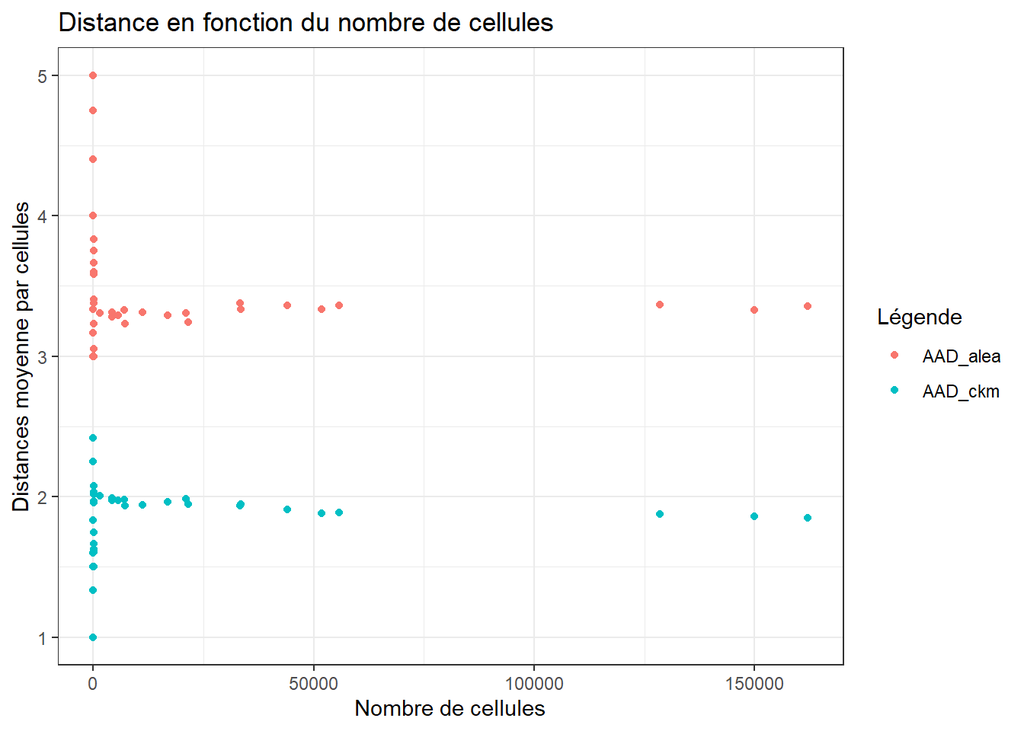

Pour la distance de Hellinger on a :

|  | Tableau | Taille | HD_ckm | HD_alea |
| --- | --- | --- | --- | --- |
| 1 | AGE3c | 4 | 0.0006816684482294773 | 0.0007254284355974981 |
| 2 | AGE3c_SEXE | 12 | 0.000854104954044447 | 0.001015648993948268 |
| 3 | CATEG | 8 | 0.0006128189001808112 | 0.001615415200154567 |
| 4 | CATEG_AGE3c | 32 | 0.001252004719242876 | 0.001855559973040268 |
| 5 | CATEG_AGE3c_SEXE | 96 | 0.001415142202765906 | 0.002374443503253711 |
| 6 | CATEG_DUR | 40 | 0.001735926237198865 | 0.002432424709524934 |
| 7 | CATEG_DUR_SEXE | 120 | 0.002163692952121783 | 0.003360285571794461 |
| 8 | CATEG_NIVFOR | 48 | 0.004669925163271258 | 0.01092525532250496 |
| 9 | CATEG_NIVFOR_SEXE | 144 | 0.007897339986037434 | 0.01704664021506335 |
| 10 | CATEG_PLGQP | 11212 | 0.1036214579332076 | 0.1930794762999274 |

[output cut: 25 more lines]

Que l’on peut representer :

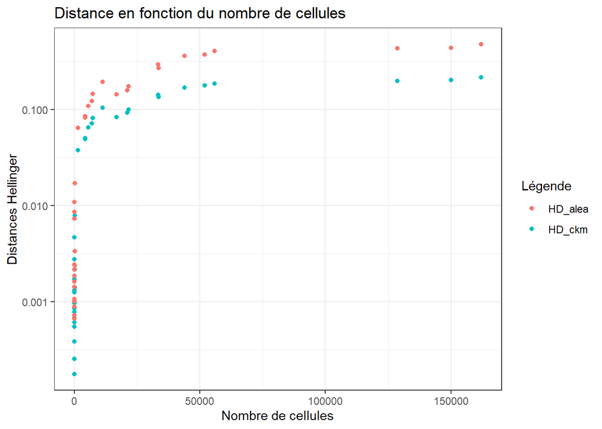

### Impact sur les mesures d’association

Une autre analyse statistique fréquemment réalisée sur les tableaux de contingence est le test d’indépendance entre les variables catégorielles qui composent le tableau. Le test d’indépendance pour un tableau à deux entrées est basé sur une statistique du Chi-deux de Pearson :

$$\chi^2 = \sum_i \sum_j \frac{(o_{ij} - e_{ij})^2}{e_{ij}}$$

où $o_{ij}$ est le nombre observé et $e_{ij} = \frac{n_{i.} \times n_{.j}}{n}$ est le nombre attendu pour la ligne $i$ et la colonne $j$. Si les lignes et les colonnes sont indépendantes, alors $\chi^2$ suit asymptotiquement une distribution du chi-deux avec $(R-1)(C-1)$ degrés de liberté. Pour des valeurs élevées, le test rejette l’hypothèse nulle en faveur de l’hypothèse alternative d’association.

Nous utilisons la mesure d’association, V de Cramer :

$$CV = \sqrt{\frac{\chi^2}{n \cdot \text{min}(R-1, C-1)}}$$

et définissons la perte d’information par la différence relative en pourcentage entre le tableau original et le tableau perturbé :

$$RCV(D_{\text{orig}}, D_{\text{pert}}) = 100 \times
\frac{CV(D_{\text{pert}}) - CV(D_{\text{orig}})}{CV(D_{\text{orig}})}$$

Le tableau suivant présente les mesures de perte d’information $RCV$ pour nos données QPV :

|  | Tableau | Taille | Taux_Variation_V_Cramer_ckm | Taux_Variation_V_Cramer_alea |
| --- | --- | --- | --- | --- |
| 1 | AGE3c_SEXE | 12 | -0.01075808449319313 | 0.002796518101398352 |
| 2 | CATEG_AGE3c | 32 | 0.00317485848368674 | -0.00524766458496547 |
| 3 | CATEG_DUR | 40 | -0.001201517865600872 | -0.001529940828708872 |
| 4 | CATEG_NIVFOR | 48 | -0.0006233538727620947 | 0.002441586890642538 |
| 5 | CATEG_PLGQP | 11212 | 0.7380670477466797 | 2.203770154461369 |
| 6 | CATEG_RSA | 24 | -0.0001388275569093076 | 0.001680208228107233 |
| 7 | CATEG_SEXE | 24 | -0.002771563888373686 | -0.0003422022077911127 |
| 8 | DUR_SEXE | 15 | -0.006233730244058014 | 0.01248596164902161 |
| 9 | NIVFOR_SEXE | 18 | -7.57719360148953e-05 | -0.002532093401057494 |
| 10 | PLGQP_AGE3c | 5609 | 0.5995308573877153 | 1.747699610468248 |

[output cut: 3 more lines]

D’autre part, les deux méthodes indiquent que les tableaux perturbés ont artificiellement plus d’associations que le tableau d’origine si le tableau comporte beaucoup de cellules et d’autant plus dans le cas de l’arrondi aléatoire. Les tableaux contenant la variable PLGQP sont particulièrement affecté .

A noter que ce résultat est independant du nombre de cellules inférieure à 10 dans les tableaux.

### Tests d’hypothèses statistiques pour détecter les biais

#### Test de Spearman

Un autre outil d’inférence statistique est la corrélation de rang de Spearman. Il s’agit d’une technique qui teste la direction et la force de la relation entre deux variables. La statistique est basée sur le classement des deux variables de la plus élevée à la plus basse et sur le calcul d’une statistique de corrélation. Une évaluation importante pour analyser l’impact des méthodes SDC sur les données statistiques consiste à vérifier si le classement des valeurs au sein des variables est faussé. Dans le cadre de la comparaison entre le tableau original (nb_obs) et le tableau perturbé (nb_obs_ckm ou nb_obs_alea), le test de Spearman permet d’évaluer si la structure des rangs des données est maintenue après perturbation.

|  | Tableau | Taille | rho_Spearman_ckm | rho_Spearman_alea | p_value_Spearman_ckm | p_value_Spearman_alea |
| --- | --- | --- | --- | --- | --- | --- |
| 1 | AGE3c | 4 | 1 | 1 | 0.08333333333333333 | 0.08333333333333333 |
| 2 | AGE3c_SEXE | 12 | 1 | 1 | 0 | 0 |
| 3 | CATEG | 8 | 1 | 1 | 4.96031746031746e-05 | 4.96031746031746e-05 |
| 4 | CATEG_AGE3c | 32 | 1 | 1 | 0 | 0 |
| 5 | CATEG_AGE3c_SEXE | 96 | 1 | 1 | 0 | 0 |
| 6 | CATEG_DUR | 40 | 0.9999999999999998 | 0.9999999999999998 | 0 | 0 |
| 7 | CATEG_DUR_SEXE | 120 | 0.9999999999999998 | 0.9999999999999998 | 0 | 0 |
| 8 | CATEG_NIVFOR | 48 | 1 | 1 | 0 | 0 |
| 9 | CATEG_NIVFOR_SEXE | 144 | 0.9999989952571112 | 0.9999989952550922 | 0 | 0 |
| 10 | CATEG_PLGQP | 11212 | 0.9983818025491196 | 0.995976057689553 | 0 | 0 |

[output cut: 25 more lines]

Une valeur de rho proche de 1 indique une forte corrélation. Cela signifie que les rangs des données originales et perturbées sont fortement liés. Alors qu’Une valeur de rho proche de 0 indique une faible corrélation, ce qui suggère que la perturbation a modifié la structure des rangs des données.

Si la valeur p est supérieure à 0.05, on ne peut pas rejeter l’hypothèse nulle. Cela signifie qu’il n’y a pas de preuve statistiquement significative de corrélation entre les deux ensembles de données. alors que Si la valeur p est inférieure ou égale à 0.05, on rejette l’hypothèse nulle. Cela signifie qu’il y a une preuve statistiquement significative de corrélation entre les deux ensembles de données.

Dans le cas de petit tableau (nb de cellules<5) et pour les deux méthodes, la p valeur est supérieur à 0.05 et donc on en conclue qu’il n’y a pas de prevue significative de corrélation entre les deux ensembles de données (originale et perturbéé)

#### Test de Wilcoxon

Nous pouvons aussi utiliser un test de classement signé de Wilcoxen pour vérifier si l’emplacement de la distribution empirique a changé. L’hypothèse nulle du test est la suivante : aucun changement. La statistique standardisée est basée sur le classement des cellules dans le tableau et tester si la somme des scores de classement pour les cellules d’origine dévie de la moyenne attendue sous l’hypothèse nulle d’égalité de localisation. S’il y a un grand écart (petite valeur p), alors on peut dire que l’emplacement de la distribution a été décalé. Le tableau suivant présente les valeurs p pour le test de classement signé de Wilcoxon.

|  | Tableau | Taille | Nb_obs_inf_10 | Nb_obs_inf_10_ckm | Nb_obs_inf_10_alea | p_value_Wilcoxon_ckm | p_value_Wilcoxon_alea |
| --- | --- | --- | --- | --- | --- | --- | --- |
| 1 | AGE3c | 4 | 0 | 0 | 0 | 0.4226780741706355 | 0.7127018566581784 |
| 2 | AGE3c_SEXE | 12 | 0 | 0 | 0 | 0.03473564402538147 | 0.0144453999894075 |
| 3 | CATEG | 8 | 0 | 0 | 0 | 0.1883126894889166 | 0.4211558651991067 |
| 4 | CATEG_AGE3c | 32 | 0 | 0 | 0 | 0.01403313435175747 | 0.8826677753917941 |
| 5 | CATEG_AGE3c_SEXE | 96 | 0 | 0 | 0 | 0.0147873021700055 | 0.06949452466207465 |
| 6 | CATEG_DUR | 40 | 0 | 0 | 0 | 0.5998625247740712 | 0.5024739112266081 |
| 7 | CATEG_DUR_SEXE | 120 | 0 | 0 | 0 | 0.9797474679246156 | 0.7314995496248744 |
| 8 | CATEG_NIVFOR | 48 | 0 | 0 | 0 | 0.7480795674268772 | 0.7731252419317854 |
| 9 | CATEG_NIVFOR_SEXE | 144 | 0 | 0 | 0 | 0.192651732645968 | 0.2870356601759168 |
| 10 | CATEG_PLGQP | 11212 | 815 | 817 | 301.4 | 0.502545534562757 | 0.4475117311354732 |

[output cut: 25 more lines]

La table montre que les perturbations ont modfiée la distributions des données sur les tableaux ayant un très grand nombre de cellules(>100 000) et un très grand nombre de petites cellules(>40 000) et d’autant plus dans le cas de la CKM ayant des p valeur inférieur à celle de l’arrondi aléatoire et donc a plus perturbé la distribution des données.

### Impact sur la variance des estimations

Les méthodes SDC auront un impact sur les variances calculées pour les estimations basées sur les tableaux de fréquence. Nous examinons la variance du nombre de cellules avant et après les méthodes SDC en calculant le taux de variation de variance.

|  | Tableau | Taille | Taux_Variation_Variance_ckm | Taux_Variation_Variance_alea |
| --- | --- | --- | --- | --- |
| 1 | AGE3c | 4 | 0.0002113936006581586 | 0.0001547217639586845 |
| 2 | AGE3c_SEXE | 12 | 0.0001234625108403575 | 0.0001396423514940787 |
| 3 | CATEG | 8 | 7.790395309107029e-05 | -5.798117677380353e-05 |
| 4 | CATEG_AGE3c | 32 | 3.318324268884533e-05 | 3.356681954831349e-05 |
| 5 | CATEG_AGE3c_SEXE | 96 | -8.786282145130086e-06 | -3.501437796408505e-06 |
| 6 | CATEG_DUR | 40 | 8.080645369789143e-06 | -0.0002353448797350058 |
| 7 | CATEG_DUR_SEXE | 120 | 9.53712077305264e-06 | -8.023402666805286e-05 |
| 8 | CATEG_NIVFOR | 48 | -9.182108527161197e-07 | -0.0002642653957660197 |
| 9 | CATEG_NIVFOR_SEXE | 144 | -1.160348570428794e-05 | -0.0001917483514247135 |
| 10 | CATEG_PLGQP | 11212 | 4.545405851696969e-06 | -6.483535950192126e-05 |

[output cut: 25 more lines]